[figure not shown]

# NORWICH UNIVERSITY CIRCLE

## About Us

### Our History

#### Omicron Delta Kappa

Omicron Delta Kappa ($\small O \Delta K$) was founded in 1914 by a group of students and faculty at Washington and Lee University in Lexington, Virginia. It was founded on the belief that collegiate leadership should be recognized and encouraged across all facets of campus life.

$\small O \Delta K$ has over 300 chapters – referred to as “circles” – and initiates around 8,000 new members annually. National membership exceeds 320,000 students and professionals across higher education, business, entertainment, sports, mass media, technology, the sciences, law, government, military service and an array of other fields.

$\small O \Delta K$ promotes its ideals through its vision and leadership values.

- **$\small O \Delta K$ Vision**
  - Omicron Delta Kappa is a multi-generational society that excels in recognizing and connecting collaborative and inclusive leaders.
- **$\small O \Delta K$ Ideals & Leadership Values**
  - **Collaboration:** Working together to achieve a defined and common purpose.
  - **Inclusivity:** Actively seeking, embracing, and advancing a diverse group of individuals.
  - **Integrity:** Aligning one’s values and beliefs with behaviors and speech.
  - **Knowledge:** Striving for excellence in academics and to pursue lifelong learning.
  - **Service:** Answering the call to action from one’s community, country, or organization.

#### Norwich University Circle

Norwich University, founded in 1819 and located in Northfield, Vermont, is the oldest private and senior military college in the United States and offers bachelor’s and master’s degrees on-campus and online (wikipedia).

The Norwich University Circle of $\small O \Delta K$ was founded in 2015. It was the first Circle established to include members from an institution’s graduate programs and one the first to include members who participated in campus life at distance through virtual platforms. The Norwich University Circle has 58 student/alumni, faculty, and honorary members as of Fall 2021.

## Candidate Info

### Application Information for Interested Candidates

#### Candidacy Eligibility and Application Process

- **You must be (1) a Current Undergraduate Student of sophomore status or higher, (2) a Current Graduate Student in the MSL Major or (3) an MBA Major with Organizational Leadership Concentration or (4) an alumni of one of those two graduate programs from Norwich University.** If you are a current graduate student, you must have completed four seminars of graduate-level work.
- **All student candiates – regardless of level – must achieve and maintain GPA of: 3.70.**
- **Complete Norwich University’s $\small O \Delta K$ Circle Application Forms**:
  - For Norwich Students/Faculty
  - [For Alumni/Non-Students](https://dynamicforms.ngwebsolutions.com/Submit/Start/0f6b1f77-bc05-44e9-b987-0c15f15ba8f0?SSO=N)
  - Also include an essay describing your demonstrated Professional Leadership results in each of Norwich University’s 4 Values-Based Leadership Dimensions. First-Person, APA 7th Edition format with Cover Page and Reference Page. Not To Exceed 1500 words. Be sure to cover all 4 dimensions:
    1. Leading the Self
    2. Leading Others
    3. Leading in Service
    4. Leading the Organization.
- **Submit two letters of testimony** supporting the above leadership results. Not to exceed 2 pages each.
- If accepted, you will need to pay one-time national dues of $88.00, one-time local dues of $50.00, and complete the $\small O \Delta K$ Application Form. Instructions on how to pay the dues will be given with your acceptance notification.

#### Acceptance and Induction

**To be inducted into $\small O \Delta K$ after you have been accepted:**

- You must fulfill participation requirements: You must achieve and maintain GPA of 3.70.
- Have demonstrated Professional Leadership excellence in one or more of Norwich University’s 4 Values-Based Leadership Dimensions.
- Received an Acceptance Letter (only the top 3% of the entire University population can beaccepted based on GPA and application).
- Complete the $\small O \Delta K$ Application and pay one-time national dues of $88.00, one-time local dues of$50.00 (due a month before the induction).
  - Active participation on at least one committee, including executive committee
  - Attendance at virtual meetings
  - Attendance at a minimum of two events per semester (in person or virtual)

Please be aware that acceptance into $\small O \Delta K$ requires active participation in the circle. Review the information below and consider which office you hope to maintain in the Norwich $\small O \Delta K$ Circle.

## Current Efforts & News

### Circle Happenings

Details to come.

#### The Cirlce of Omicron Delta Kappa Publication

$\small O \Delta K$ publishes a magazine called [**The Circle**](https://odk.org/get-involved/thecircle/) which can be accessed using the link.

#### Upcoming National Events

A current list of National $\small O \Delta K$ events can be found [here](https://odk.org/circle-officers/dates-and-deadlines/). A few recurring annual events of note include $\small O \Delta K$’s **National Leadership Conference** (June 2-5, 2022) and **National Day of Service** (April 14, 2022).

#### Strategic Plan

$\small O \Delta K$ has initiated a 2022-2024 Strategic Plan. It has 3 goals and 12 objectives as detailed below:

1. Provide and excellent, relevant campus member and circle experience.
   - Provide greater support for advisors.
   - Unify and understand circle programming.
   - Invest in a targeted redevelopment plan for under-performing circles in order to develop a sustainable culture that offers a premium and relevant experience.
   - Redevelop extension practices to ensure new circles establish a sustainable culture and the desired reputation on campus.
   - Develop strategies to assess and encourage high-level circle performance.
2. Build a more diverse and inclusive organization.
   - Create incentives for circles to recruit, induct, and engage more graduate, professional, faculty, staff, alumni, and community members including honorary members.
   - Develop and implement policies that ensure equitable access to membership for historically marginalized and underrepresented individuals.
   - Establish new pathways for non-campus individuals to join Omicron Delta Kappa.
3. Champion and celebrate collaborative and inclusive leadership.
   - Develop strategies for greater celebration and engagement of individual members.
   - Develop a national marketing campaign to clearly communicate the Society’s mission and impact among all audiences, including those not on campus.
   - Develop a national communications program (free and paid media) on the topic of collaborative and inclusive leadership.
   - Sponsor events, prizes, and activities that celebrate and recognize collaborative leadership.

## Circle Members

### Membership Benefits

#### Scholarships

Omicron Delta Kappa awards more than 40 [Scholarships](https://odk.org/get-involved/scholarships/) per year to help collegiate members continue graduate and professional studies.

#### Other Membership Benefits

Check out other membership benefits [here](https://odk.org/members/benefits-membership/).

### Organizations represented by Circle Members

- Norwich University
- United States Army
- United States Marine Corps
- United States Air Force
- International Rescue Committee
- ISE Consulting
- Jacobs Naval Systems
- Jewish Federation of Sarasota-Manaty
- New Mexico State University - Los Alamos Neutron Science Center
- Pepco Holdings, Inc.
- Scaled Composites, LLC
- Select Medical
- T. Rowe Price

### Circle Officers

Student Officers (e.g. President, Vice President, Treasurer) of the Norwich University circle undertake the following responsibilities:

- Establish a regular circle meeting schedule as well as officer meetings
- Work with circle coordinator and faculty adviser to set the circle’s calendar for the year ensuring that membership selection, reporting, and initiation happen in a timely manner
- Facilitate goal setting
- Encourage, support, and motivate circle
- Update college or university administrators on the circle’s activities
- Be familiar with national bylaws as well as the circle’s bylaws and policies
- Work with circle coordinator and faculty adviser to ensure minimum circle standards are being met
- Host an orientation for new members, explaining $\small O \Delta K$’s history and purpose and their obligations as members
- Preside over induction ceremony
- Help maintain circle documents
- Determine appropriate programming for the campus
- Ensure circle is represented at national convention and regional drive-in workshops
- Encourage members to remain in contact with $\small O \Delta K$ after graduation

## Analytics

Total Norwich University Circle Members = 58

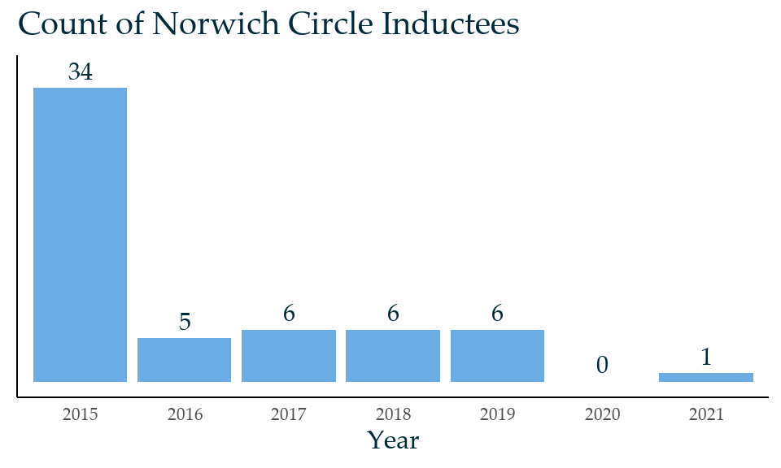

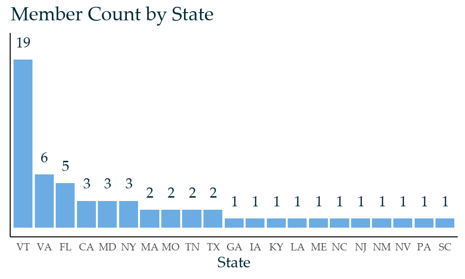

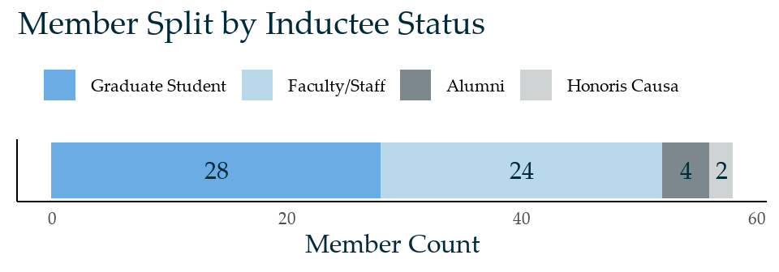

## Leadership Tools & Social Media

### National Social Media

- [ODK HQ YouTube](https://www.youtube.com/channel/UCv2JhK5ltEU18yvMQkb1J1w)
- [ODK HQ Instagram](https://www.instagram.com/odk_hq/)
- [ODK1914 on Twitter](https://twitter.com/ODK1914)
- [ODK MeritPages](https://odk.meritpages.com/)
- [ODK LinkedIn](https://www.linkedin.com/groups/144429/)
- [ODK Facebook](https://www.facebook.com/OmicronDeltaKappa)

### Leadership Resources

#### Norwich Circle Book Recommendations

- Leadership
  - The 21 Irrefutable Laws of Leadership by John Maxwell
  - Culture Code by Daniel Coyle
  - Extreme Ownership by Jocko Willink
  - Fierce Conversations by Susan Scott
  - Multipliers by Liz Wiseman
  - Leader as Coach by David Peterson
  - The Leadership Challenge by James Kouzes and Barry Posner
  - Radical Candor by Kim Scott
  - Radical Inclusion by Martin Dempsey
- Facilitation, Organizational Learning, & Change Management
  - The Fifth Discipline by Peter Senge
  - How the Way We Talk Can Change the Way We Work by Robert Kegan and Lis Lahey
  - Leading Change by John Kotter
  - The Skilled Facilitator by Roger Schwarz
- Self-Development & Productivity
  - 12 Rules for Life: An antidote to chaos by Jordan Peterson
  - Atomic Habits by James Clear
  - Deep Work by Cal Newport
  - Emotional Agility by Susan David
  - Grit by Angela Duckworth
  - Insight: Why we’re not as self-aware as we think… by Tasha Eurich
  - Learned Optimism by Martin Seligman
  - Mindset by Carol Dweck
  - Social Intelligence by Karl Albrecht
  - What Got You Here Won’t Get You There by Marshall Goldsmith
  - Working Identity by Hermina Ibarra

#### Leadership Influencers

- **[The Art of Self-Coaching](https://www.edbatista.com/the-art-of-self-coaching-public-course.html) by Ed Batista. An absolute must.**
- [3x5 Leadership](https://3x5leadership.com/articles/series/): Leadership development from a West Point and Ivy League graduate.
- [Jocko Podcast](https://jockopodcast.com/jocko-podcast-books/): Landing page will be the books covered in various episodes.
- [Coaching for Leaders](https://coachingforleaders.com/) with Dave Stachowiak.
- [EntreLeadership](https://www.ramseysolutions.com/shows/the-entreleadership-podcast): Ramsey Solutions
- [Adam Grant](https://www.adamgrant.net/writing/articles/) articles.
- [Leadership podcast ideas.](https://blog.feedspot.com/leadership_podcasts/)

#### Publications

- [Harvard Business Review](https://hbr.org/)
- [MIT Sloan Management Review](https://sloanreview.mit.edu/)
- [McKinsey Quarterly](https://www.mckinsey.com/quarterly/the-magazine)
- [Other notable journals (Benedictine University)](https://researchguides.ben.edu/organization-development)

#### Coaching and Self-Development

- [The Art of Self-Coaching](https://www.edbatista.com/the-art-of-self-coaching-public-course.html) by Ed Batista. In case you missed it above.
- [Simplify Magazine](https://simplifymagazine.com/issues/): Excellent for leading self.
- [Find a coach!](https://www.coach.me/find-a-coach): coach.me

#### Productivity Tools

- [Habit Hub: Routine & Schedule app](https://apps.apple.com/us/app/habit-hub-routine-schedule/id1149192857): Free. Awesome for habit development.
- [Cozi Calendar](https://www.cozi.com/calendar/): Free. A great shared family/team calendar app.
- [Trello](https://trello.com/home) Kanban board app great for project management.

#### Change Management

- [Prosci Blog](https://blog.prosci.com/): Ideas for influencing change.
- [Change Management Review](https://www.changemanagementreview.com/)

#### Leadership-focused Organizations

- [Center for Creative Leadership](https://www.ccl.org/)

#### Leadership Academia

- Norwich University’s [Master of Science in Leadership](https://online.norwich.edu/academic-programs/masters/leadership)
- Northwestern University’s [KelloggInsight](https://insight.kellogg.northwestern.edu/)
- Stanford University’s [Leadership Insights](https://www.gsb.stanford.edu/insights/leadership)
- INSEAD [Knowledge](https://knowledge.insead.edu/)
- Georgetown University’s [Institute for Transformational Leadership](https://scs.georgetown.edu/departments/37/institute-for-transformational-leadership/)
- Benedictine University’s [Center for Values-Driven Leadership](https://cvdl.ben.edu/)
- University of Maryland’s [Center for Leadership, Innovation and Change](https://www.rhsmith.umd.edu/centers/clic)

#### Books / Reading Lists

- [McKinsey on Books](https://www.mckinsey.com/featured-insights/mckinsey-on-books): Check out the books in the Organizational Behavior section.
- [3x5 Leadership Bookshelf](https://3x5leadership.com/bookshelf/bookshelf-readinglist/)
- [U.S. Military Professional Reading Lists](https://library.citadel.edu/professionalreadinglist)